# Project Python Foundations: FoodHub Data Analysis

### **Question 7**: Which are the top 5 restaurants in terms of the number of orders received? [1 mark]

```python
# Top 5 restaurants by order count
top_restaurants = df['restaurant_name'].value_counts().head(5)
print("Top 5 restaurants by order count:")
print(top_restaurants)
```

```
Top 5 restaurants by order count:
Shake Shack                  219
The Meatball Shop            132
Blue Ribbon Sushi            119
Blue Ribbon Fried Chicken     96
Parm                          68
Name: restaurant_name, dtype: int64
```

**Observations:** Shake Shack is the leading restaurant with 219 orders, The Meatball Shop, Blue Ribbon Sushi, Blue Ribbon Fried Chicken & Parm have 132, 119, 96 & 68 orders respectively.

1. Shake Shack (219 orders):

Clearly the most popular, with a significantly higher order count compared to others.

1. The Meatball Shop (132 orders):

Maintains a substantial number of orders, suggesting consistent popularity.

1. Blue Ribbon Sushi (119 orders):

A notable presence, indicating a preference for sushi among customers.

1. Blue Ribbon Fried Chicken (96 orders):

Despite specializing in fried chicken, it has a considerable order count, showcasing its popularity.

1. Parm (68 orders):

While lower in order count compared to the top contenders, Parm still holds a notable position in the top 5.

Overall, this ranking provides insights into customer preferences, highlighting Shake Shack as a standout favorite, followed by a mix of establishments catering to different culinary preferences.

### **Question 8**: Which is the most popular cuisine on weekends? [1 mark]

```python
df[df['day_of_the_week'] =='Weekend'].groupby('cuisine_type').count().sort_values(by = 'order_id',axis = 0, ascending=False).head(5)
```

| cuisine_type | order_id | customer_id | restaurant_name | cost_of_the_order | day_of_the_week | rating | food_preparation_time | delivery_time |
| --- | --- | --- | --- | --- | --- | --- | --- | --- |
| American | 415 | 415 | 415 | 415 | 415 | 415 | 415 | 415 |
| Japanese | 335 | 335 | 335 | 335 | 335 | 335 | 335 | 335 |
| Italian | 207 | 207 | 207 | 207 | 207 | 207 | 207 | 207 |
| Chinese | 163 | 163 | 163 | 163 | 163 | 163 | 163 | 163 |
| Mexican | 53 | 53 | 53 | 53 | 53 | 53 | 53 | 53 |

**Observations:** American Cuisine is the most popular during the weekends with a count of 415 orders.

### **Question 9**: What percentage of the orders cost more than 20 dollars? [2 marks]

```python
# Write the code here#
total_observations = df['cost_of_the_order'].count()
orders_above20 = df['cost_of_the_order'][df['cost_of_the_order']> 20].count()
percentage_above20 = round((orders_above20/total_observations)*100,2) # Rounded to two decimal places
percentage_above20
```

```
29.24
```

**Observations:**29.24% of total orders cost more than 20 dollars.

### **Question 10**: What is the mean order delivery time? [1 mark]

```python
round(df.delivery_time.mean(),1)
```

```
24.2
```

#### Observations: It takes 24.2 minutes to have the prepared orders delivered on average.

### **Question 11:** The company has decided to give 20% discount vouchers to the top 3 most frequent customers. Find the IDs of these customers and the number of orders they placed. [1 mark]

```python
# Write the code here
df[['order_id','customer_id']].groupby('customer_id').count().sort_values(by = 'order_id',axis = 0, ascending=False).head(10)
```

| customer_id | order_id |
| --- | --- |
| 52832 | 13 |
| 47440 | 10 |
| 83287 | 9 |
| 250494 | 8 |
| 65009 | 7 |
| 82041 | 7 |
| 259341 | 7 |
| 276192 | 7 |
| 60052 | 6 |
| 115213 | 6 |

#### Observations:

The top 3 customer IDs are 52832 (order placed- 13), 47440 (orders placed- 10), 83287 (orders placed 9).

### **Question 12**: Perform a multivariate analysis to explore relationships between the important variables in the dataset. (It is a good idea to explore relations between numerical variables as well as relations between numerical and categorical variables) [10 marks]

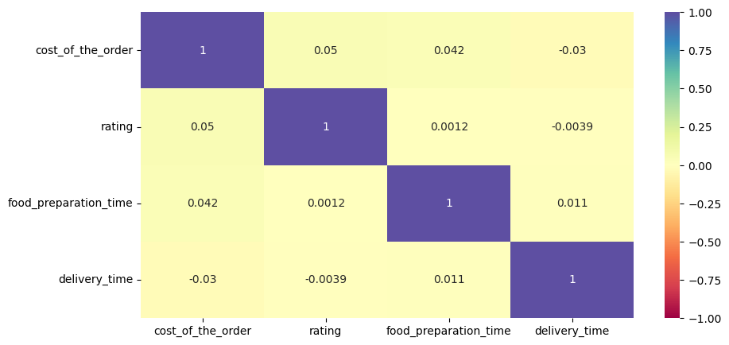

```python
# Write the code here
import matplotlib.pyplot as plt
import seaborn as sns

plt.figure(figsize=(10,5)) #Set the figure size
sns.heatmap(df.corr(numeric_only=True),annot=True,cmap='Spectral',vmin=-1,vmax=1)
plt.show()
```

**Observation**: The heatmap reveals a very weak correlation between the variables.

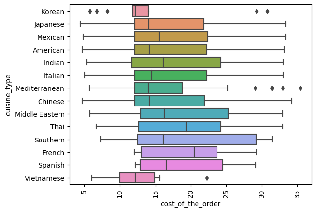

```python
sns.boxplot(data=df,x='cost_of_the_order',y='cuisine_type')
plt.xticks(rotation=90)
plt.show();
```

**Observations on Spread Cost of Order**:

General Spread:

Most cuisines exhibit varying degrees of skewed cost distributions, indicating a diversity in order pricing.

Outliers:

Cuisines like Korean, Mediterranean, and Vietnamese stand out with outliers, suggesting some orders in these categories have significantly higher costs compared to the majority. These observations highlight the diversity in cost structures among different cuisines, with certain cuisines showing a wider range due to the presence of outliers.

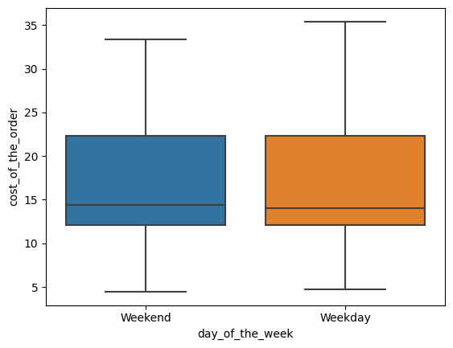

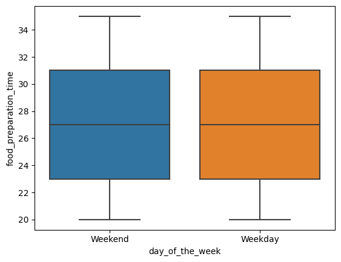

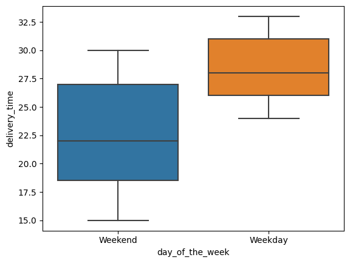

```python
sns.boxplot(data=df,x='day_of_the_week',y='cost_of_the_order')
plt.show()
sns.boxplot(data=df,x='day_of_the_week',y='food_preparation_time')
plt.show()
sns.boxplot(data=df,x='day_of_the_week',y='delivery_time')
plt.show()
```

**Observations on Day of the week against the other variables:**

Overall Spread:

Across the days of the week, there is a generally steady spread of observations for most variables, indicating a consistent pattern.

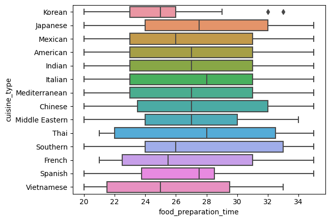

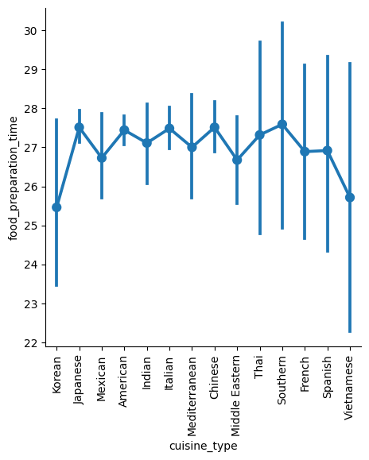

```python
sns.boxplot(data=df,x='food_preparation_time',y='cuisine_type')
plt.show()
sns.catplot(data = df, x = 'cuisine_type',y = 'food_preparation_time',kind = 'point')
plt.xticks(rotation=90)
plt.show();
```

**Observation:** Average Preparation Time:

Most cuisine types exhibit a similar average preparation time, suggesting a general consistency in the time it takes to prepare dishes across various cuisines.

Spread of 95% Confidence Interval:

However, there is variability in the spread of the 95% confidence interval among different cuisine types. Some cuisines may have a larger spread, indicating a greater range of preparation times within that cuisine. This observation implies that while the average preparation time is consistent, certain cuisines may have more variability in the time it takes to prepare individual orders.

### **Question 13:** The company wants to provide a promotional offer in the advertisement of the restaurants. The condition to get the offer is that the restaurants must have a rating count of more than 50 and the average rating should be greater than 4. Find the restaurants fulfilling the criteria to get the promotional offer. [3 marks]

```python
#returns the top-five restaurants by total number of orders with ratings
df.groupby('restaurant_name')['rating'].count().sort_values(ascending=False).reset_index().head()
```

|  | restaurant_name | rating |
| --- | --- | --- |
| 0 | Shake Shack | 219 |
| 1 | The Meatball Shop | 132 |
| 2 | Blue Ribbon Sushi | 119 |
| 3 | Blue Ribbon Fried Chicken | 96 |
| 4 | Parm | 68 |

```python
# Group by restaurant and calculate average rating and rating count
restaurant_ratings = df.groupby('restaurant_name')['rating'].agg(['mean', 'count']).reset_index()

# Filter for average rating more than 4 and rating count more than 50
filtered_restaurants = restaurant_ratings[(restaurant_ratings['mean'] > 4) & (restaurant_ratings['count'] > 50)]

print(filtered_restaurants)
```

```
Empty DataFrame
Columns: [restaurant_name, mean, count]
Index: []
```

```python
# Group by restaurant and calculate average rating and rating count
restaurant_ratings = df.groupby('restaurant_name')['rating'].agg(['mean', 'count']).reset_index()

# Filter for average rating more than 4 and rating count more than 50
filtered_restaurants = restaurant_ratings[(restaurant_ratings['mean'] > 4) & (restaurant_ratings['count'] > 50)]

# Display the result or handle empty DataFrame
if not filtered_restaurants.empty:
    print(filtered_restaurants)
else:
    print("No restaurants meet the specified criteria.")
```

```
No restaurants meet the specified criteria.
```

#### **Observations**:No restaurants meet the specified criteria of rating count of more than 50 and the average rating should be greater than 4.

### **Question 14:** The company charges the restaurant 25% on the orders having cost greater than 20 dollars and 15% on the orders having cost greater than 5 dollars. Find the net revenue generated by the company across all orders. [3 marks]

```python
# Write the code here
revenue = 0
income = 0
cost = pd.Series(df['cost_of_the_order'])
for i in range(len(cost)):
    if (cost[i] > 5) & (cost[i] < 20):
        income = cost[i]*0.15
    elif (cost[i] > 20):
        income = cost[i]*0.25
    else:
        income = 0
    revenue = revenue + income
```

```python
print('Net revenue generated is: ',round(revenue,2),'assuming no commission charged for orders with cost below $5')
```

```
Net revenue generated is:  6166.3 assuming no commission charged for orders with cost below $5
```

**Observations**:The revenue calculation of $6166 assumes that orders with a cost below $5 incur no commission charges suggesting a specific pricing or commission strategy based on order cost brackets, potentially designed to incentivize lower-cost orders.

### **Question 15:** The company wants to analyze the total time required to deliver the food. What percentage of orders take more than 60 minutes to get delivered from the time the order is placed? (The food has to be prepared and then delivered.) [2 marks]

```python
long_delivery_orders = (df['food_preparation_time'] + df['delivery_time'] > 60).mean() * 100
print(f"Percentage of orders taking more than 60 minutes for delivery: {long_delivery_orders:.2f}%")
```

```
Percentage of orders taking more than 60 minutes for delivery: 10.54%
```

**Observations**:Approximately 10.54% of orders in the dataset take more than 60 minutes to both prepare and deliver. This observation highlights a portion of orders experiencing a longer processing and delivery time, indicating a potential area for improvement or investigation into factors contributing to extended wait times for these specific orders.

### **Question 16:** The company wants to analyze the delivery time of the orders on weekdays and weekends. How does the mean delivery time vary during weekdays and weekends? [2 marks]

```python
# Write the code here

avr_del_time = df.groupby('day_of_the_week')[['delivery_time']].agg(['mean','sum','count','std'])
avr_del_time
```

| day_of_the_week | delivery_time mean | delivery_time sum | delivery_time count | delivery_time std |
| --- | --- | --- | --- | --- |
| Weekday | 28.340037 | 15502 | 547 | 2.891428 |
| Weekend | 22.470022 | 30357 | 1351 | 4.628938 |

**Observations**:

Weekday:

Mean Delivery Time: Approximately 28.34 minutes. Total Delivery Time: 15,502 minutes. Number of Orders (Count): 547 orders. Standard Deviation: 2.89 minutes. Indicates longer average delivery times during weekdays. Weekend:

Mean Delivery Time: Approximately 22.47 minutes. Total Delivery Time: 30,357 minutes. Number of Orders (Count): 1,351 orders. Standard Deviation: 4.63 minutes. Suggests shorter average delivery times during weekends.

These observations reveal a difference in mean delivery times between weekdays and weekends. Further analysis could explore factors contributing to this variation and assess its impact on customer satisfaction or operational efficiency.

### Conclusion and Recommendations

### **Question 17:** What are your conclusions from the analysis? What recommendations would you like to share to help improve the business? (You can use cuisine type and feedback ratings to drive your business recommendations.) [6 marks]

### Conclusions:

Rating Patterns: The concentration of ratings around the high score of 5 suggests that mainly very satisfied customers bother to rate the service. However, the absence of ratings for about 38% of orders raises the question of potential skewing if these unrated orders were considered.

Cost of Orders: The bimodal distribution of cost with peaks around $13 and $25 indicates a varied pricing structure, possibly catering to different customer preferences or menu options.

Cuisine Popularity: Cuisine popularity remains consistent regardless of the day of the week, but demand significantly increases over the weekends.

Preparation and Delivery Times: Preparation time is relatively consistent across cuisines, while delivery time exhibits a wider range, contributing significantly to the total preparation time.

Customer Reward Criteria: There is a tie among 4 customers for the 5th position based on the proposed reward criteria. Further analysis or decision-making is required on how to handle such ties.

Dataset Insights: The dataset contains valuable information about customer orders, restaurant performance, and delivery times. Wide ranges in delivery times, especially orders taking more than 60 minutes, could impact customer satisfaction. Certain restaurants stand out as highly popular, receiving a substantial number of orders. These conclusions provide a comprehensive overview of various aspects within the dataset, highlighting areas for further analysis and potential business considerations.

Recommendations

Enhance Customer Feedback:

Implement a systematic feedback collection process post-order. Employ surveys or interactive methods to understand the reasons behind customers not providing ratings. Introduce a rewarding system for customers consistently offering valuable feedback.

Precision in Marketing:

Conduct a thorough demographic analysis to validate assumptions about market segments. Tailor marketing strategies based on customer data to effectively reach specific segments.

Boost Operational Efficiency:

Undertake a comprehensive review of food preparation and delivery processes to identify and mitigate bottlenecks. Explore technology solutions and process enhancements to reduce overall delivery times.

Weekday Ordering Optimization:

Investigate factors contributing to extended delivery times on weekdays, addressing issues like traffic or order processing. Foster transparent communication with customers, providing clear expectations for delivery times on weekdays.

Refined Tie-Breaker Criteria:

Establish transparent criteria for resolving ties in promotional offers. Consider implementing a tiered reward system based on factors such as total spending or loyalty points.

Dynamic Performance Evaluation:

Conduct regular performance reviews encompassing restaurant performance, customer satisfaction, and promotional offer effectiveness. Adapt strategies promptly based on evolving trends and customer preferences.

Engaging Customer Loyalty:

Launch a well-designed customer loyalty program with tangible incentives for frequent orders. Promote the loyalty program through diverse channels to encourage widespread participation. These refined recommendations aim to elevate customer satisfaction, streamline operational processes, and foster customer loyalty. Regular assessments and agility in adapting strategies will be pivotal in navigating the dynamic landscape of the market.